# Lecture 6: Simulation and Propensity Scores

Intro to Data Science for Public Policy, Spring 2016

by Jeff Chen & Dan Hammer, Georgetown University McCourt School of Public Policy

The objective of any good data science is to avoid work. Any work. And especially math. Why spend time working out a closed-form solution when you can simulate the answer just as easily? Consider, for example, trying to calculate the [standard errors on a complicated regression model](http://www.ssc.wisc.edu/~bhansen/econometrics/Econometrics2011.pdf#page=256)? It is far easier to simulate the answer, rather than calculate it directly.

This lecture will offer a cursory review of calculating a consistent estimate of a policy treatment through simulation and propensity score matching. Entire books have been written about this subject, and this lecture doesn’t come close to a full treatment. However, as an illustration of the value of simulation in data science, the propensity score applications are particularly expository.

We first set up a **data generating process**. Normally, in the real world, we don’t observe the data generating process directly. It is a complex and unobservable function of variables, which may or may not be observed. We try to back out components of these variables for empirical analysis of policy impacts.

Let $D_i$ be the indicator of treatment for observation $i = 1, 2, \ldots, N$; let $Y_i$ be the outcome variable; and let $X_i$ be the vector of observable characteristics, which affect the propensity for receiving treatment:
$$\begin{equation}
\label{eq:basic}
Y_i = \delta D_i + \beta X_i + \epsilon_i, \hspace{6pt}\mbox{with}\hspace{6pt} \epsilon_i \sim N(0,1)
\end{equation}$$

Assume further that there are three observable characteristics $x_1, x_2, x_3 \sim Unif(0,1)$ and that treatment is determined by the following rule:

$$\begin{equation}
D_i = \Bigg \{ \begin{array}{rl}
1 & \mbox{if $\, 2(x_{1i} + x_{2i} + x_{3i}) + u_i > 4$}, \\
0 & \mbox{otherwise}
\end{array}
\end{equation}$$

where $u_i \sim N(0,1)$. Note that if we run a linear regression without conditioning on $X_i$, the treatment effect will be biased, since the composite error term will be correlated with both treatment and outcome. With this framework, we can construct a data set of size $N = 5000$ in order to examine the behavior of various estimation techniques.

```r
N <- 5000; eps <- rnorm(N); u <- rnorm(N)
x1 <- runif(N); x2 <- runif(N); x3 <- runif(N)
D <- ifelse(2*(x1 + x2 + x3) + u > 4, 1, 0)
Y <- D + x1 + x2 + x3 + eps
summary(D); summary(Y)
```

```
   Min. 1st Qu.  Median    Mean 3rd Qu.    Max.
  0.000   0.000   0.000   0.252   1.000   1.000
```

```
   Min. 1st Qu.  Median    Mean 3rd Qu.    Max.
-2.2600  0.8186  1.6820  1.7400  2.6420  6.2300
```

Roughly one quarter of the observations received treatment, and the outcome variable has about a ten unit spread, centered around 1.5 or 2.

For reference, we estimate to basic, linear models by ordinary least squares. First, we do not condition on the $X$ covariates, which will yield biased estimates of the treatment effect — which is known. We bootstrap the distribution of the estimated treatment effect. We sample $n = 500$ observations from the distribution, estimate the impact effect, and repeat for $B=5000$ iterations. Note that we do not iterate using a `for` loop, but rather by applying the `ols` function, defined below, to a range of indices using `sapply` to keep the code compact and readable.

```r
n <- 500; B <- 5000
X <- cbind(1, D)

ols <- function(i) {
    idx <- sample.int(N,n)
    Xs <- X[idx,]
    b <- solve(t(Xs) %*% Xs) %*% t(Xs) %*% Y[idx]
    b[2]
}

res.ols <- data.frame(impact=sapply(1:B, ols), method=c("ols"))
```

Before we graph the distribution, let’s perform the same process for the estimated impact, conditioning on $X$. This should yield a consistent estimator for the treatment effect $\delta$, since by construction there is no three-way covariation between the error, outcome, *and* treatment, after conditioning on the observables.

```r
X.ext <- cbind(1, D, x1, x2, x3)

mult.ols <- function(i) {
    idx <- sample.int(N,n)
    Xs <- X.ext[idx,]
    b <- solve(t(Xs) %*% Xs) %*% t(Xs) %*% Y[idx]
    b[2]
}

res.mult <- data.frame(impact=sapply(1:B, mult.ols), method=c("mult.ols"))
total.res <- rbind(res.ols, res.mult)
```

Now we can plot the two distributions of impact estimates, based on the method of estimation. The vertical line in Figure indicates the true, known impact effect. It is clear that the OLS estimates with omitted variables overstate the treatment effect, since there is selection into the treatment group.

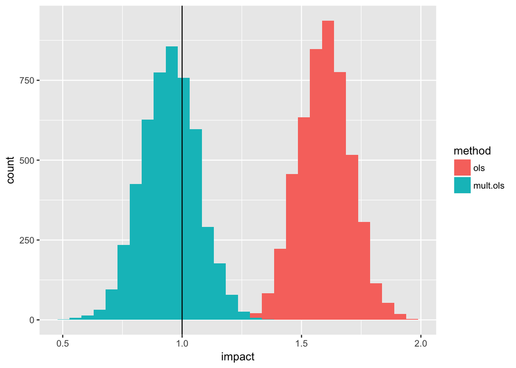

```r
  library(ggplot2)
  p <- ggplot(total.res, aes(x=impact, fill=method))
  p <- p + geom_histogram(position="identity")
  p + geom_vline(xintercept = 1)
```